# Enough Bioconductor to be dangerous

Andrew McDavid

2018-02-07

# Bioconductor

- [Bioconductor](http://www.bioconductor.org) is an open source, open development software project to provide tools for the analysis and comprehension of high-throughput genomic data.
- Most Bioconductor components are distributed as R packages. The functional scope of Bioconductor packages includes the analysis of DNA microarray, sequence, flow, SNP, and other data.
- Statistical and computational methods and **data**: interfaces to PubMed, annotation data from Entrez genes, experiments from ArrayExpress, GEO and the SRA.
- Thousands of packages. There are methods, experimental and annotation data. Take a look: http://bioconductor.org/packages/release/BiocViews.html
- The following is adapted from the [Bioconductor RNA-seq workflow](http://bioconductor.org/help/workflows/rnaseqGene/) by Mike Love, Simon Anders and Vladislav Kim.

# Sequence data

Sequence data are often passed around in text files called FASTQ. There seems not to be a formal specification for them, but here’s an example:

```
@SEQ_ID
GATTTGGGGTTCAAAGCAGTATCGATCAAATAGTAAATCCATTTGTTCAACTCACAGTTT
+
!''*((((***+))%%%++)(%%%%).1***-+*''))**55CCF>>>>>>CCCCCCC65
```

Each **read** of the sequencer is represented by four lines, so FASTQ files can be many millions of lines long.

The **aligner** (program that maps raw sequences to locations in a reference genome) uses FASTQ files.

# Binary formats

A common binary format for aligned data is the **bam** (binary alignment format). This gives the genomic locations that could have potentially generated a read, and their probabilities. These can be used by **read counting** algorithms to estimate the number of reads that came from a gene, an ingredient for determining the expression of the gene.

```r
indir <- system.file("extdata", package="airway", mustWork=TRUE)
```

In this directory, we find the eight BAM files (and some other files):

```r
list.files(indir)
```

```
##  [1] "GSE52778_series_matrix.txt"
##  [2] "Homo_sapiens.GRCh37.75_subset.gtf"
##  [3] "sample_table.csv"
##  [4] "SraRunInfo_SRP033351.csv"
##  [5] "SRR1039508_subset.bam"
##  [6] "SRR1039509_subset.bam"
##  [7] "SRR1039512_subset.bam"
##  [8] "SRR1039513_subset.bam"
##  [9] "SRR1039516_subset.bam"
## [10] "SRR1039517_subset.bam"
## [11] "SRR1039520_subset.bam"
## [12] "SRR1039521_subset.bam"
```

# Sample table

Typically, we have a table with detailed information for each of our samples that links samples to the associated FASTQ and BAM files. For your own project, you might create such a comma-separated value (CSV) file using a text editor or spreadsheet software such as Excel.

We load such a CSV file with *read.csv*:

```r
csvfile <- file.path(indir, "sample_table.csv")
sampleTable <- read.csv(csvfile, row.names = 1)
sampleTable
```

```
##            SampleName    cell   dex albut        Run avgLength Experiment
## SRR1039508 GSM1275862  N61311 untrt untrt SRR1039508       126  SRX384345
## SRR1039509 GSM1275863  N61311   trt untrt SRR1039509       126  SRX384346
## SRR1039512 GSM1275866 N052611 untrt untrt SRR1039512       126  SRX384349
## SRR1039513 GSM1275867 N052611   trt untrt SRR1039513        87  SRX384350
## SRR1039516 GSM1275870 N080611 untrt untrt SRR1039516       120  SRX384353
## SRR1039517 GSM1275871 N080611   trt untrt SRR1039517       126  SRX384354
## SRR1039520 GSM1275874 N061011 untrt untrt SRR1039520       101  SRX384357
## SRR1039521 GSM1275875 N061011   trt untrt SRR1039521        98  SRX384358
##               Sample    BioSample
## SRR1039508 SRS508568 SAMN02422669
## SRR1039509 SRS508567 SAMN02422675
## SRR1039512 SRS508571 SAMN02422678
## SRR1039513 SRS508572 SAMN02422670
## SRR1039516 SRS508575 SAMN02422682
## SRR1039517 SRS508576 SAMN02422673
## SRR1039520 SRS508579 SAMN02422683
## SRR1039521 SRS508580 SAMN02422677
```

Once the reads have been aligned, there are a number of tools that can be used to count the number of reads/fragments that can be assigned to genomic features for each sample. These often take as input SAM/BAM alignment files and a file specifying the genomic features, e.g. a GFF3 or GTF file specifying the gene models.

# Gene models

Regardless of the method of quantitation, we will need a gene model. This is a mapping between transcripts/isoforms and base-pair locations in the genome.

These are often provided as [GTF files](http://www.ensembl.org/info/website/upload/gff.html) (Flicek et al. 2014), and can be read using *makeTxDbFromGFF* from the *GenomicFeatures* package. GTF files can be downloaded from [Ensembl’s FTP site](http://www.ensembl.org/info/data/ftp/) or other gene model repositories. A *TxDb* object is a database that can be used to generate a variety of range-based objects, such as exons, transcripts, and genes. We want to make a list of exons grouped by gene for counting read/fragments.

There are other options for constructing a *TxDb*. For the *known genes* track from the UCSC Genome Browser (Kent et al. 2002), one can use the pre-built Transcript Database: *TxDb.Hsapiens.UCSC.hg19.knownGene*. If the annotation file is accessible from *AnnotationHub* (as is the case for the Ensembl genes), a pre-scanned GTF file can be imported using *makeTxDbFromGRanges*.

Here we will demonstrate loading from a GTF file:

```r
library("GenomicFeatures")
```

We indicate that none of our sequences (chromosomes) are circular using a 0-length character vector.

```r
gtffile <- file.path(indir,"Homo_sapiens.GRCh37.75_subset.gtf")
txdb <- makeTxDbFromGFF(gtffile, format = "gtf", circ_seqs = character())
txdb
```

```
## TxDb object:
## # Db type: TxDb
## # Supporting package: GenomicFeatures
## # Data source: /Users/amcdavid/Library/R/3.4-bioc/library/airway/extdata/Homo_sapiens.GRCh37.75_subset.gtf
## # Organism: NA
## # Taxonomy ID: NA
## # miRBase build ID: NA
## # Genome: NA
## # transcript_nrow: 65
## # exon_nrow: 279
## # cds_nrow: 158
## # Db created by: GenomicFeatures package from Bioconductor
## # Creation time: 2017-10-25 01:12:40 -0400 (Wed, 25 Oct 2017)
## # GenomicFeatures version at creation time: 1.28.5
## # RSQLite version at creation time: 2.0
## # DBSCHEMAVERSION: 1.1
```

The following line produces a *GRangesList* of all the exons grouped by gene (Lawrence et al. 2013). Each element of the list is a *GRanges* object of the exons for a gene.

```r
ebg <- exonsBy(txdb, by="gene")
ebg
```

```
## GRangesList object of length 20:
## $ENSG00000009724
## GRanges object with 18 ranges and 2 metadata columns:
##        seqnames               ranges strand |   exon_id       exon_name
##           <Rle>            <IRanges>  <Rle> | <integer>     <character>
##    [1]        1 [11086580, 11087705]      - |        98 ENSE00000818830
##    [2]        1 [11090233, 11090307]      - |        99 ENSE00000472123
##    [3]        1 [11090805, 11090939]      - |       100 ENSE00000743084
##    [4]        1 [11094885, 11094963]      - |       101 ENSE00000743085
##    [5]        1 [11097750, 11097868]      - |       102 ENSE00003482788
##    ...      ...                  ...    ... .       ...             ...
##   [14]        1 [11106948, 11107176]      - |       111 ENSE00003467404
##   [15]        1 [11106948, 11107176]      - |       112 ENSE00003489217
##   [16]        1 [11107260, 11107280]      - |       113 ENSE00001833377
##   [17]        1 [11107260, 11107284]      - |       114 ENSE00001472289
##   [18]        1 [11107260, 11107290]      - |       115 ENSE00001881401
##
## ...
## <19 more elements>
## -------
## seqinfo: 1 sequence from an unspecified genome; no seqlengths
```

# Counting reads

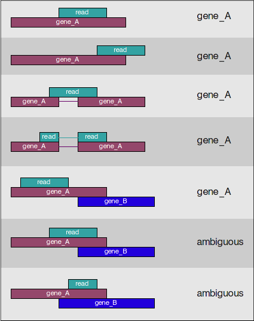

Feature counting with a “union” gene model

Each of scenario 1-5 would result in one count for gene_A. The total number of counts depends on: 1. The number of cDNA fragments that came from gene_A. Longer genes tend to produce more fragments. 2. How easy it is to map them to gene_A. Genes with many homologs will tend to be harder to map. 3. How deeply we sequenced.

## What the FPKM?[^1]

Let $X_{i}$ represent the number of **counts** generated by some feature $i$. Because of mapping uncertainty, we don’t directly observe $X_i$, but can use some estimate, such as $E(X_i)$.

## Counts per million (CPM)

We might try to control for (3) by scaling by the total number of reads, and multiplying by one million (so we aren’t dealing with tiny fractions). This gives us **counts per million** (CPM):
$$\text{CPM}_i = 10^6 X_i/N,$$
where $N = sum_i X_i$.

Feature $i$ has some **effective length** $l_i$. It is *effective* because the far ends of a transcript typically can’t produce a sequence-able fragment due to size selection steps in the protocols.

## Transcripts per million (TPM)

Longer features generate more counts, so scale each count by the effective length of the transcript, which gives us counts per basepair: $X_i/l_i$. Then if we normalize by the total number of counts per basepair, and multiply by $10^6$ we get **transcripts per million** (TPM)
$$\text{TPM}_i = \frac{X_i/l_i}{\sum_i X_i/l_i} 10^6.$$
Transcripts per million is actually trying to directly estimate the relative abundances of various transcripts. It says if you started with 1 million transcripts of varying lengths, how many of a given species would you expect to see?

## Fragments per kilobase per million reads

Finally, sometimes reads are reported as **fragments per kilobase per million** (FPKM). In symbols
$$\text{FPKM}_i = \frac{X_i}{l_i/10^3 \times N/10^6} = \frac{X_i/l_i}{N} 10^9.$$
This is analogous to TPM, but with another factor of $10^3$ and with a denominator that doesn’t account for the differing emission probabilities of other transcripts.

**All of these are only appropriate for within-sample normalization.**

# But you really shouldn’t just count reads

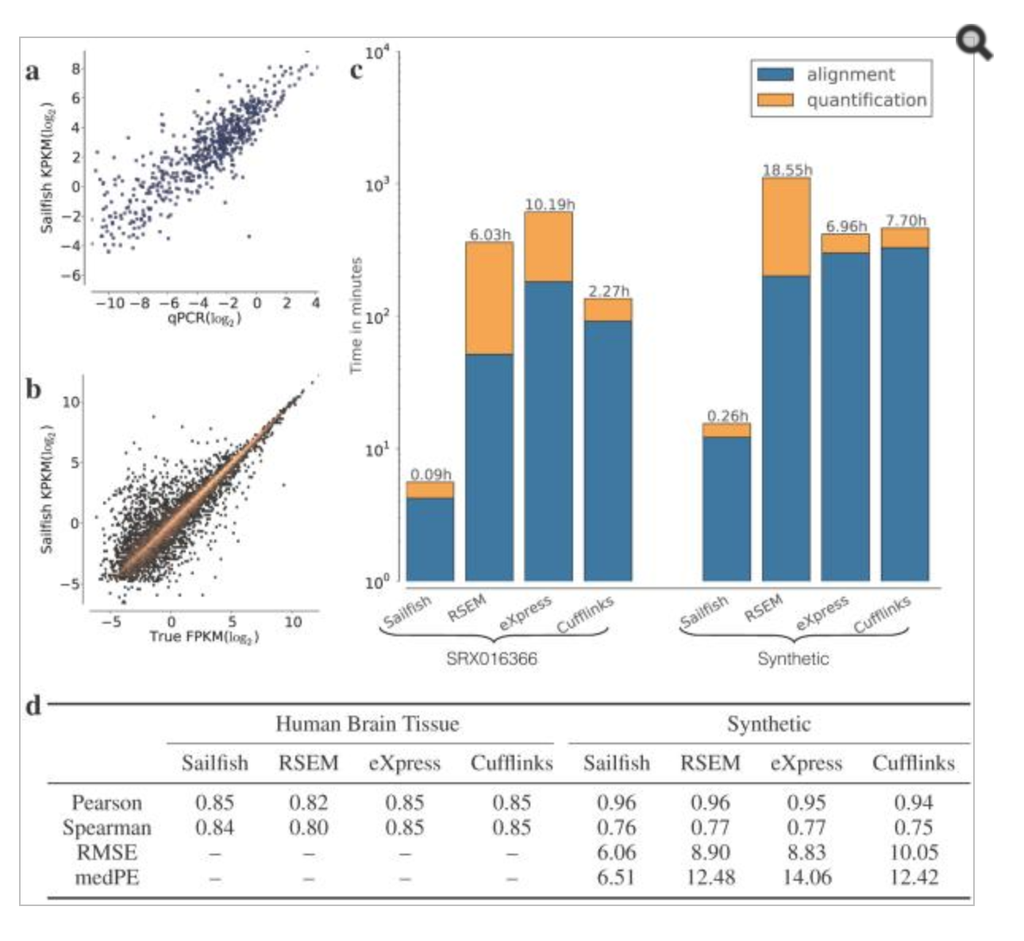

Statistical models for RNAseq are faster, and more accurate than read counting

From Patro, Mount and Kingsford (2014).

# Across sample normalization[^2]

**Normalization** is a crucial step when analyzing RNAseq and microarray data.

In the case of RNAseq, we are adjusting for:

- Amount/concentration of starting material
- Sequencing depth
- Gene length

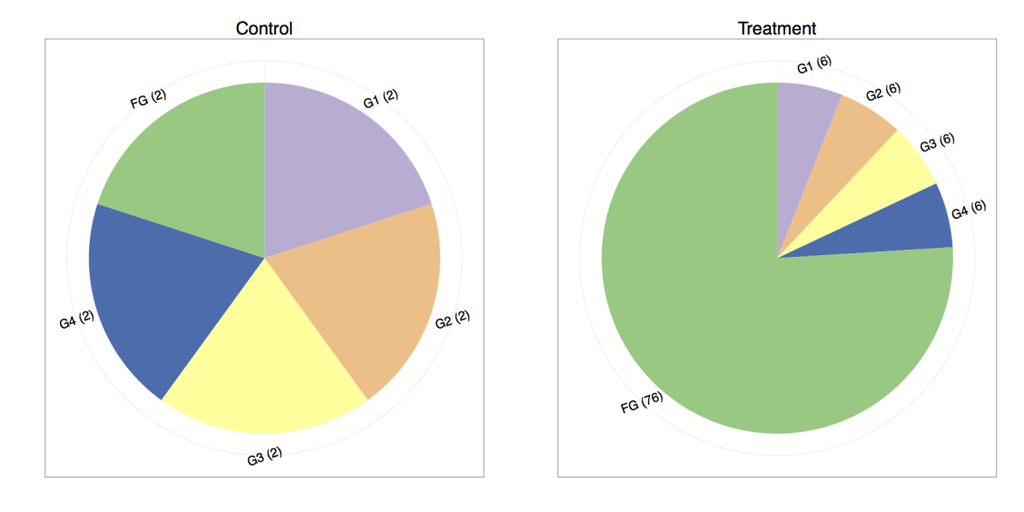

A hypothetical gene expression experiment from Harold Pimentel’s [excellent blog](https://haroldpimentel.wordpress.com/category/statistics-2/).

Suppose each of these genes is a kilobase in effective length, so that CPM = TPM = RPKM. The control experimental has 10 reads sequenced, while the treatment has 100. In terms of counts:

| Gene | Control | Treatment |
| --- | --- | --- |
| G1 | 2 | 6 |
| G2 | 2 | 6 |
| G3 | 2 | 6 |
| G4 | 2 | 6 |
| FG | 2 | 76 |

In terms of fractions:

| Gene | Control | Treatment |
| --- | --- | --- |
| G1 | .2 | .06 |
| G2 | .2 | .06 |
| G3 | .2 | .06 |
| G4 | .2 | .06 |
| FG | .2 | .76 |

It seems that most of the genes did not change expression. Instead, we should have omitted the Funky Gene from the scaling factor. Between-sample normalization methods are ways to attempt to estimate the set of non-funky genes.

# Normalization - TMM

The Trimmed Mean of M-values (TMM) method of Robinson & Oshlack is one of the most typically used methods. By default, the packages `edgeR` and `Limma` use the TMM normalization strategy. `DESeq2` also employs a robust estimate (the median).

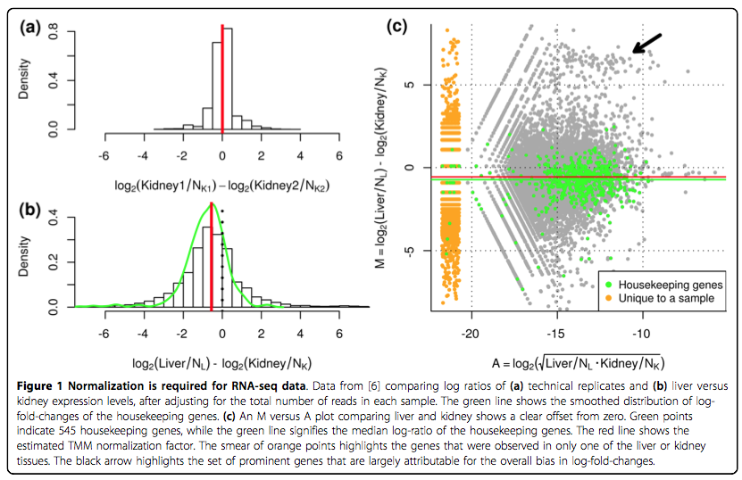

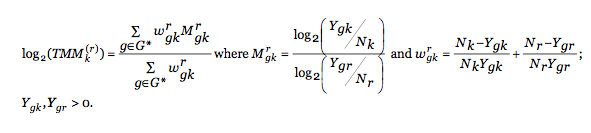

A trimmed mean is the average after removing the upper and lower x% of the data. The TMM procedure is doubly trimmed, by trimming both the M and A values. By default, they propose to trim the Mg values by 30% and the Ag values by 5%. $G^*$ is the set of non-trimmed genes and $w^r_{gk}$ are weights, putting higher weight on genes with higher expression (hence lower log-variance).

# Importing quantitated RNAseq data

The following tools can be used generate count matrices: *summarizeOverlaps* (Lawrence et al. 2013), *featureCounts* (Liao, Smyth, and Shi 2014), *tximport* (Soneson, Love, and Robinson 2015) (my recommendation), *htseq-count* (Anders, Pyl, and Huber 2015).

| function | package | framework | output | *DESeq2* input function |
| --- | --- | --- | --- | --- |
| *summarizeOverlaps* | *GenomicAlignments* | R/Bioconductor | *SummarizedExperiment* | *DESeqDataSet* |
| *featureCounts* | *Rsubread* | R/Bioconductor | matrix | *DESeqDataSetFromMatrix* |
| *tximport* | *tximport* | R/Bioconductor | list of matrices | *DESeqDataSetFromTximport* |
| *htseq-count* | HTSeq | Python | files | *DESeqDataSetFromHTSeq* |

# SummarizedExperiment objects

After all this, we will try to produce a `SummarizedExperiment` object that packages an expression matrix with information about the rows and columns of said matrix.

```r
library(airway)
data("airway")
se <- airway
```

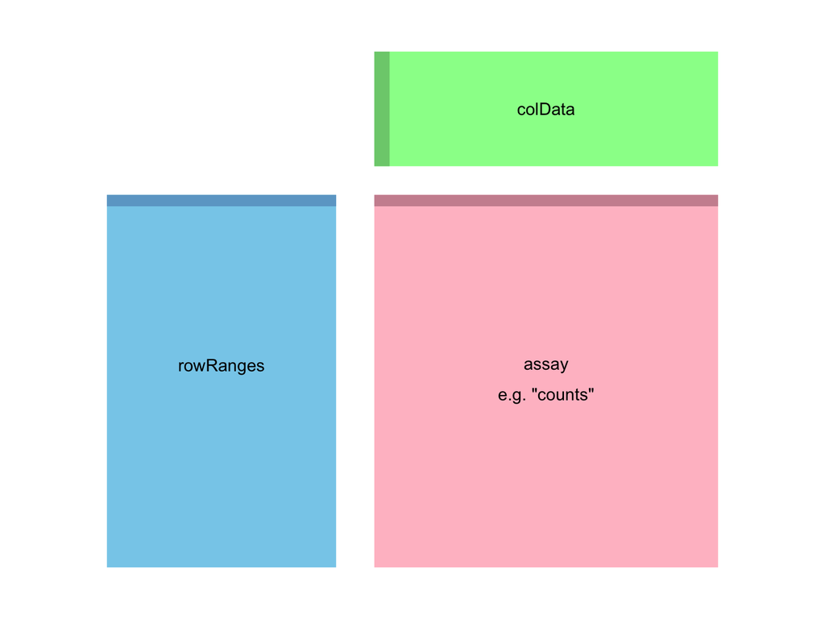

- `assay`: (pink) matrix of counts
- `rowRanges` (blue) information about the genomic ranges
- `colData` (green block) samples.

# Example

```r
se
```

```
## class: RangedSummarizedExperiment
## dim: 64102 8
## metadata(1): ''
## assays(1): counts
## rownames(64102): ENSG00000000003 ENSG00000000005 ... LRG_98 LRG_99
## rowData names(0):
## colnames(8): SRR1039508 SRR1039509 ... SRR1039520 SRR1039521
## colData names(9): SampleName cell ... Sample BioSample
```

```r
dim(se)
```

```
## [1] 64102     8
```

```r
assayNames(se)
```

```
## [1] "counts"
```

```r
head(assay(se), 3)
```

```
##                 SRR1039508 SRR1039509 SRR1039512 SRR1039513 SRR1039516
## ENSG00000000003        679        448        873        408       1138
## ENSG00000000005          0          0          0          0          0
## ENSG00000000419        467        515        621        365        587
##                 SRR1039517 SRR1039520 SRR1039521
## ENSG00000000003       1047        770        572
## ENSG00000000005          0          0          0
## ENSG00000000419        799        417        508
```

```r
colSums(assay(se))
```

```
## SRR1039508 SRR1039509 SRR1039512 SRR1039513 SRR1039516 SRR1039517
##   20637971   18809481   25348649   15163415   24448408   30818215
## SRR1039520 SRR1039521
##   19126151   21164133
```

The `rowRanges`, when printed, only shows the first *GRanges*, and tells us there are 64102 elements.

```r
rowRanges(se)
```

```
## GRangesList object of length 64102:
## $ENSG00000000003
## GRanges object with 17 ranges and 2 metadata columns:
##        seqnames               ranges strand |   exon_id       exon_name
##           <Rle>            <IRanges>  <Rle> | <integer>     <character>
##    [1]        X [99883667, 99884983]      - |    667145 ENSE00001459322
##    [2]        X [99885756, 99885863]      - |    667146 ENSE00000868868
##    [3]        X [99887482, 99887565]      - |    667147 ENSE00000401072
##    [4]        X [99887538, 99887565]      - |    667148 ENSE00001849132
##    [5]        X [99888402, 99888536]      - |    667149 ENSE00003554016
##    ...      ...                  ...    ... .       ...             ...
##   [13]        X [99890555, 99890743]      - |    667156 ENSE00003512331
##   [14]        X [99891188, 99891686]      - |    667158 ENSE00001886883
##   [15]        X [99891605, 99891803]      - |    667159 ENSE00001855382
##   [16]        X [99891790, 99892101]      - |    667160 ENSE00001863395
##   [17]        X [99894942, 99894988]      - |    667161 ENSE00001828996
##
## ...
## <64101 more elements>
## -------
## seqinfo: 722 sequences (1 circular) from an unspecified genome
```

The `colData`:

```r
colData(se)
```

```
## DataFrame with 8 rows and 9 columns
##            SampleName     cell      dex    albut        Run avgLength
##              <factor> <factor> <factor> <factor>   <factor> <integer>
## SRR1039508 GSM1275862   N61311    untrt    untrt SRR1039508       126
## SRR1039509 GSM1275863   N61311      trt    untrt SRR1039509       126
## SRR1039512 GSM1275866  N052611    untrt    untrt SRR1039512       126
## SRR1039513 GSM1275867  N052611      trt    untrt SRR1039513        87
## SRR1039516 GSM1275870  N080611    untrt    untrt SRR1039516       120
## SRR1039517 GSM1275871  N080611      trt    untrt SRR1039517       126
## SRR1039520 GSM1275874  N061011    untrt    untrt SRR1039520       101
## SRR1039521 GSM1275875  N061011      trt    untrt SRR1039521        98
##            Experiment    Sample    BioSample
##              <factor>  <factor>     <factor>
## SRR1039508  SRX384345 SRS508568 SAMN02422669
## SRR1039509  SRX384346 SRS508567 SAMN02422675
## SRR1039512  SRX384349 SRS508571 SAMN02422678
## SRR1039513  SRX384350 SRS508572 SAMN02422670
## SRR1039516  SRX384353 SRS508575 SAMN02422682
## SRR1039517  SRX384354 SRS508576 SAMN02422673
## SRR1039520  SRX384357 SRS508579 SAMN02422683
## SRR1039521  SRX384358 SRS508580 SAMN02422677
```

# Assignment, subseting

Again, we want to specify that `untrt` is the reference level for the dex variable:

```r
se$dex = se$dex %>% relevel("untrt")
se$dex
```

```
## [1] untrt trt   untrt trt   untrt trt   untrt trt
## Levels: untrt trt
```

We can quickly check the millions of fragments that uniquely aligned to the genes (the second argument of *round* tells how many decimal points to keep).

```r
round( colSums(assay(se)) / 1e6, 1 )
```

```
## SRR1039508 SRR1039509 SRR1039512 SRR1039513 SRR1039516 SRR1039517
##       20.6       18.8       25.3       15.2       24.4       30.8
## SRR1039520 SRR1039521
##       19.1       21.2
```

## Subsampling

If we wanted to take a subsample of genes (perhaps prior to testing a slow machine learning technique, **cough**)

```r
se_samp = se[sample(nrow(se), 1000),]
dim(se_samp)
```

```
## [1] 1000    8
```

This samples 1000 genes without replacement.  
Q: How could you take only the 1000 most variable genes?

# Differential expression

Our next goal is to test for differential expression, given conditions 1 and 2, test if
$$H_0: \mu_{i1} = \mu_{i2}.$$
where eg $\mu_{i1} = E(Y_{ij} | \text{condition 1})$. Thus we have one test per gene, so ~64,000 tests.

# A cornucopia of differential expression methods

There are quite a few Bioconductor packages for exploration and differential expression of the count data, including:

- *edgeR* (M. D. Robinson, McCarthy, and Smyth 2009),
- *limma* with the voom method (my favorite) (Law et al. 2014),
- *DSS* (H. Wu, Wang, and Wu 2013),
- *EBSeq* (Leng et al. 2013) and
- *baySeq* (Hardcastle and Kelly 2010).

Schurch et al. (2016) [compared performance](https://www.ncbi.nlm.nih.gov/pmc/articles/pmid/27022035/) of different statistical methods can provide guidance on power calculations.

# Negative binomial models

A common model for RNAseq (Robinson and Smyth [2007,2008]) is:
$$Y_{ij}=\mathrm{NegBinom}(w_{ij}N_{j}, \phi)$$

where $w_{ij}$ is the normalized rate of emission of gene $i$ in sample $j$, and $N_{j}$ is the total read count for sample $j$. $N_{j}$ basically accounts for sequencing depth variability from sample-to-sample. $\phi$ is the dispersion parameter.

The following parametrization is often of use:
$$\mathbb{E}(Y_{ij})=\mu_{ij}\quad \mathrm{and}\quad \mathrm{Var}(Y_{ij})=\mu_{ij}(1+\mu_{ij}\phi)$$

where $\mu_{ij}=w_{ij}N_{j}$. In this parametrization the Poisson distribution can be seen as a special case when $\phi=0$.

## Estimation

The genewise dispersion parameters are estimated by conditional maximum likelihood, conditioning on the total count for that gene (Smyth and Verbyla, 1996). An empirical Bayes procedure is used to shrink the dispersions towards a consensus value, effectively borrowing information between genes (Robinson and Smyth, 2007).

# Containers for DESeq2

Bioconductor software packages often define and use a custom class for storing data: *DESeq2* uses a *DESeqDataSet*. It is built on top of the *SummarizedExperiment* class, with a few minor constraints enforced.

For instance, the *DESeqDataSet* has an associated *design formula* specified at the beginning of the analysis, informing many of the *DESeq2* functions how to treat the samples in the analysis

For the airway experiment, we will specify `~ cell + dex` meaning that we want to test for the effect of dexamethasone (`dex`) controlling for the effect of different cell line (`cell`). We can see each of the columns just using the `$` directly on the *SummarizedExperiment* or *DESeqDataSet*:

```r
se$cell
```

```
## [1] N61311  N61311  N052611 N052611 N080611 N080611 N061011 N061011
## Levels: N052611 N061011 N080611 N61311
```

```r
se$dex
```

```
## [1] untrt trt   untrt trt   untrt trt   untrt trt
## Levels: untrt trt
```

```r
dds <- DESeqDataSet(se, design = ~ cell + dex)
```

# DESeq2 differential expression pipeline

As we have already specified an experimental design when we created the *DESeqDataSet*, we can run the differential expression pipeline on the raw counts with a single call to the function *DESeq*:

```r
dds <- DESeq(dds)
```

This function will print out a message for the various steps it performs. These are described in more detail in the manual page for *DESeq*, which can be accessed by typing `?DESeq`. Briefly these are: the estimation of size factors (controlling for differences in the sequencing depth of the samples), the estimation of dispersion values for each gene, and fitting a generalized linear model.

A *DESeqDataSet* is returned that contains all the fitted parameters within it, and the following section describes how to extract out results tables of interest from this object.

# Building the results table

Calling *results* without any arguments will extract the estimated log2 fold changes and *p* values for the last variable in the design formula. If there are more than 2 levels for this variable, *results* will extract the results table for a comparison of the last level over the first level. The comparison is printed at the top of the output: `dex trt vs untrt`.

```r
res <- results(dds)
res
```

```
## log2 fold change (MLE): dex trt vs untrt
## Wald test p-value: dex trt vs untrt
## DataFrame with 64102 rows and 6 columns
##                  baseMean log2FoldChange     lfcSE       stat       pvalue
##                 <numeric>      <numeric> <numeric>  <numeric>    <numeric>
## ENSG00000000003 708.60217    -0.38125388 0.1006560 -3.7876928 0.0001520527
## ENSG00000000005   0.00000             NA        NA         NA           NA
## ENSG00000000419 520.29790     0.20681271 0.1122218  1.8428925 0.0653447023
## ENSG00000000457 237.16304     0.03792050 0.1434532  0.2643405 0.7915175170
## ENSG00000000460  57.93263    -0.08816322 0.2871677 -0.3070095 0.7588361136
## ...                   ...            ...       ...        ...          ...
## LRG_94                  0             NA        NA         NA           NA
## LRG_96                  0             NA        NA         NA           NA
## LRG_97                  0             NA        NA         NA           NA
## LRG_98                  0             NA        NA         NA           NA
## LRG_99                  0             NA        NA         NA           NA
##                        padj
##                   <numeric>
## ENSG00000000003 0.001283937
## ENSG00000000005          NA
## ENSG00000000419 0.196568379
## ENSG00000000457 0.911483176
## ENSG00000000460 0.895073113
## ...                     ...
## LRG_94                   NA
## LRG_96                   NA
## LRG_97                   NA
## LRG_98                   NA
## LRG_99                   NA
```

We could have equivalently produced this results table with the following more specific command. Because `dex` is the last variable in the design, we could optionally leave off the `contrast` argument to extract the comparison of the two levels of `dex`.

```r
res <- results(dds, contrast=c("dex","trt","untrt"))
```

# Interpreting results

`res` is a *DataFrame* object and helpfully carries metadata with information on the meaning of the columns:

```r
mcols(res, use.names = TRUE)
```

```
## DataFrame with 6 rows and 2 columns
##                        type                               description
##                 <character>                               <character>
## baseMean       intermediate mean of normalized counts for all samples
## log2FoldChange      results  log2 fold change (MLE): dex trt vs untrt
## lfcSE               results          standard error: dex trt vs untrt
## stat                results          Wald statistic: dex trt vs untrt
## pvalue              results       Wald test p-value: dex trt vs untrt
## padj                results                      BH adjusted p-values
```

- `baseMean`, average of the normalized count values, divided by the size factors, taken over all samples in the *DESeqDataSet*.
- `log2FoldChange` is the effect size estimate. It tells us how much the gene’s expression seems to have changed due to treatment with dexamethasone in comparison to untreated samples. This value is reported on a logarithmic scale to base 2: for example, a log2 fold change of 1.5 means that the gene’s expression is increased by a multiplicative factor of $2^{1.5} \approx 2.82$.
- `lfcSE`, the standard error estimate for the log2 fold change estimate.
- `pvalue` *hypothesis test* against the *null hypothesis* that there is zero effect of the treatment

## Quick summary

We can also summarize the results with the following line of code, which reports some additional information, that will be covered in later sections.

```r
summary(res)
```

```
##
## out of 33469 with nonzero total read count
## adjusted p-value < 0.1
## LFC > 0 (up)     : 2604, 7.8%
## LFC < 0 (down)   : 2212, 6.6%
## outliers [1]     : 0, 0%
## low counts [2]   : 15441, 46%
## (mean count < 5)
## [1] see 'cooksCutoff' argument of ?results
## [2] see 'independentFiltering' argument of ?results
```

Note that there are many genes with differential expression due to dexamethasone treatment at the FDR level of 10%. This makes sense, as the smooth muscle cells of the airway are known to react to glucocorticoid steroids.

How could we provide a prioritized list of genes by effect size?

## NA values

When all counts for a gene were zero, or if the gene was excluded from analysis because it contained an extreme count outlier.

# Other comparisons

In general, the results for a comparison of any two levels of a variable can be extracted using the `contrast` argument to *results*. The user should specify three values: the name of the variable, the name of the level for the numerator, and the name of the level for the denominator. Here we extract results for the log2 of the fold change of one cell line over another:

```r
results(dds, contrast = c("cell", "N061011", "N61311"))
```

```
## log2 fold change (MLE): cell N061011 vs N61311
## Wald test p-value: cell N061011 vs N61311
## DataFrame with 64102 rows and 6 columns
##                  baseMean log2FoldChange     lfcSE        stat     pvalue
##                 <numeric>      <numeric> <numeric>   <numeric>  <numeric>
## ENSG00000000003 708.60217     0.30632635 0.1435330  2.13418733 0.03282745
## ENSG00000000005   0.00000             NA        NA          NA         NA
## ENSG00000000419 520.29790    -0.05404672 0.1597205 -0.33838315 0.73507447
## ENSG00000000457 237.16304     0.01630854 0.2030380  0.08032261 0.93598068
## ENSG00000000460  57.93263     0.27912688 0.4007042  0.69659093 0.48605883
## ...                   ...            ...       ...         ...        ...
## LRG_94                  0             NA        NA          NA         NA
## LRG_96                  0             NA        NA          NA         NA
## LRG_97                  0             NA        NA          NA         NA
## LRG_98                  0             NA        NA          NA         NA
## LRG_99                  0             NA        NA          NA         NA
##                      padj
##                 <numeric>
## ENSG00000000003 0.2201807
## ENSG00000000005        NA
## ENSG00000000419 0.9390808
## ENSG00000000457 0.9903711
## ENSG00000000460 0.8548857
## ...                   ...
## LRG_94                 NA
## LRG_96                 NA
## LRG_97                 NA
## LRG_98                 NA
## LRG_99                 NA
```

There are additional ways to build results tables for certain comparisons after running *DESeq* once. If results for an interaction term are desired, the `name` argument of *results* should be used. Please see the help page for the *results* function for details on the additional ways to build results tables. In particular, the **Examples** section of the help page for *results* gives some pertinent examples.

# Multiple testing

In high-throughput biology, we are careful to not use the *p* values directly as evidence against the null, but to correct for *multiple testing*. What would happen if we were to simply threshold the *p* values at a low value, say 0.05? There are 5676 genes with a *p* value below 0.05 among the 33469 genes for which the test succeeded in reporting a *p* value:

```r
sum(res$pvalue < 0.05, na.rm=TRUE)
```

```
## [1] 5676
```

```r
sum(!is.na(res$pvalue))
```

```
## [1] 33469
```

Now, assume for a moment that the null hypothesis is true for all genes, i.e., no gene is affected by the treatment with dexamethasone. Then, by the definition of the *p* value, we expect up to 5% of the genes to have a *p* value below 0.05. This amounts to 1673 genes. If we just considered the list of genes with a *p* value below 0.05 as differentially expressed, this list should therefore be expected to contain up to 1673 / 5676 = 29% false positives.

*DESeq2* uses the Benjamini-Hochberg (BH) adjustment (Benjamini and Hochberg 1995) as implemented in the base R *p.adjust* function; in brief, this method calculates for each gene an adjusted *p* value that answers the following question: if one called significant all genes with an adjusted *p* value less than or equal to this gene’s adjusted *p* value threshold, what would be the fraction of false positives (the *false discovery rate*, FDR) among them, in the sense of the calculation outlined above? These values, called the BH-adjusted *p* values, are given in the column `padj` of the `res` object.

The FDR is a useful statistic for many high-throughput experiments, as we are often interested in reporting or focusing on a set of interesting genes, and we would like to put an upper bound on the percent of false positives in this set.

Hence, if we consider a fraction of 10% false positives acceptable, we can consider all genes with an adjusted *p* value below 10% = 0.1 as significant. How many such genes are there?

```r
sum(res$padj < 0.1, na.rm=TRUE)
```

```
## [1] 4816
```

We subset the results table to these genes and then sort it by the log2 fold change estimate to get the significant genes with the strongest down-regulation:

```r
resSig <- subset(res, padj < 0.1)
head(resSig[ order(resSig$log2FoldChange), ])
```

```
## log2 fold change (MLE): dex trt vs untrt
## Wald test p-value: dex trt vs untrt
## DataFrame with 6 rows and 6 columns
##                  baseMean log2FoldChange     lfcSE      stat       pvalue
##                 <numeric>      <numeric> <numeric> <numeric>    <numeric>
## ENSG00000128285  6.624741      -5.325912 1.2578863 -4.234017 2.295537e-05
## ENSG00000267339 26.233573      -4.611553 0.6731316 -6.850894 7.338997e-12
## ENSG00000019186 14.087605      -4.325920 0.8578247 -5.042895 4.585398e-07
## ENSG00000183454  5.804171      -4.264087 1.1669498 -3.654045 2.581412e-04
## ENSG00000146006 46.807597      -4.211875 0.5288797 -7.963767 1.668799e-15
## ENSG00000141469 53.436528      -4.124784 1.1297977 -3.650905 2.613174e-04
##                         padj
##                    <numeric>
## ENSG00000128285 2.382495e-04
## ENSG00000267339 2.057658e-10
## ENSG00000019186 6.623843e-06
## ENSG00000183454 2.051926e-03
## ENSG00000146006 7.180217e-14
## ENSG00000141469 2.073517e-03
```

…and with the strongest up-regulation:

```r
head(resSig[ order(resSig$log2FoldChange, decreasing = TRUE), ])
```

```
## log2 fold change (MLE): dex trt vs untrt
## Wald test p-value: dex trt vs untrt
## DataFrame with 6 rows and 6 columns
##                   baseMean log2FoldChange     lfcSE      stat       pvalue
##                  <numeric>      <numeric> <numeric> <numeric>    <numeric>
## ENSG00000179593  67.243048       9.505972 1.0545111  9.014578 1.976299e-19
## ENSG00000109906 385.071029       7.352628 0.5363902 13.707610 9.141988e-43
## ENSG00000250978  56.318194       6.327393 0.6778153  9.334981 1.010098e-20
## ENSG00000132518   5.654654       5.885113 1.3241367  4.444491 8.810031e-06
## ENSG00000127954 286.384119       5.207160 0.4930828 10.560419 4.546302e-26
## ENSG00000249364   8.839061       5.098168 1.1596852  4.396166 1.101798e-05
##                         padj
##                    <numeric>
## ENSG00000179593 1.254532e-17
## ENSG00000109906 2.257695e-40
## ENSG00000250978 7.226210e-19
## ENSG00000132518 1.002065e-04
## ENSG00000127954 5.059304e-24
## ENSG00000249364 1.226124e-04
```

# Plotting results

## Counts plot

A quick way to visualize the counts for a particular gene is to use the *plotCounts* function that takes as arguments the *DESeqDataSet*, a gene name, and the group over which to plot the counts (figure below).

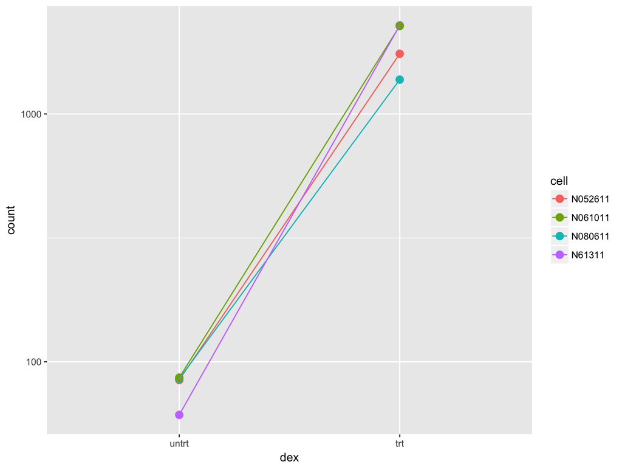

```r
topGene <- rownames(res)[which.min(res$padj)]
library("ggbeeswarm")
geneCounts <- plotCounts(dds, gene = topGene, intgroup = c("dex","cell"),
                         returnData = TRUE)
ggplot(geneCounts, aes(x = dex, y = count, color = cell, group = cell)) +
  scale_y_log10() + geom_point(size = 3) + geom_line()
```

**Normalized counts with lines connecting cell lines.** Based on this figure, would you conclude there is evidence of an interaction between cellline and treatment?

# Exploratory analysis and visualization

Next we will consider *transformations of the counts* in order to visually explore sample relationships.

## Pre-filtering the dataset

Our count matrix with our *DESeqDataSet* contains many rows with only zeros, and additionally many rows with only a few fragments total. In order to reduce the size of the object, and to increase the speed of our functions, we can remove the rows that have no or nearly no information about the amount of gene expression. Here we apply the most minimal filtering rule: removing rows of the *DESeqDataSet* that have no counts, or only a single count across all samples. Additional weighting/filtering to improve power is applied at a later step in the workflow.

```r
nrow(dds)
```

```
## [1] 64102
```

```r
dds <- dds[ rowSums(counts(dds)) > 1, ]
nrow(dds)
```

```
## [1] 29391
```

# Variance stabilizing transformations

Many common statistical methods for exploratory analysis of multidimensional data, for example clustering and *principal components analysis* (PCA), work best for data that generally has the same range of variance at different ranges of the mean values: *homoskedastic*. We can quickly show this property of counts with some simulated data (here, Poisson counts with a range of lambda from 0.1 to 100). We plot the standard deviation of each row (genes) against the mean:

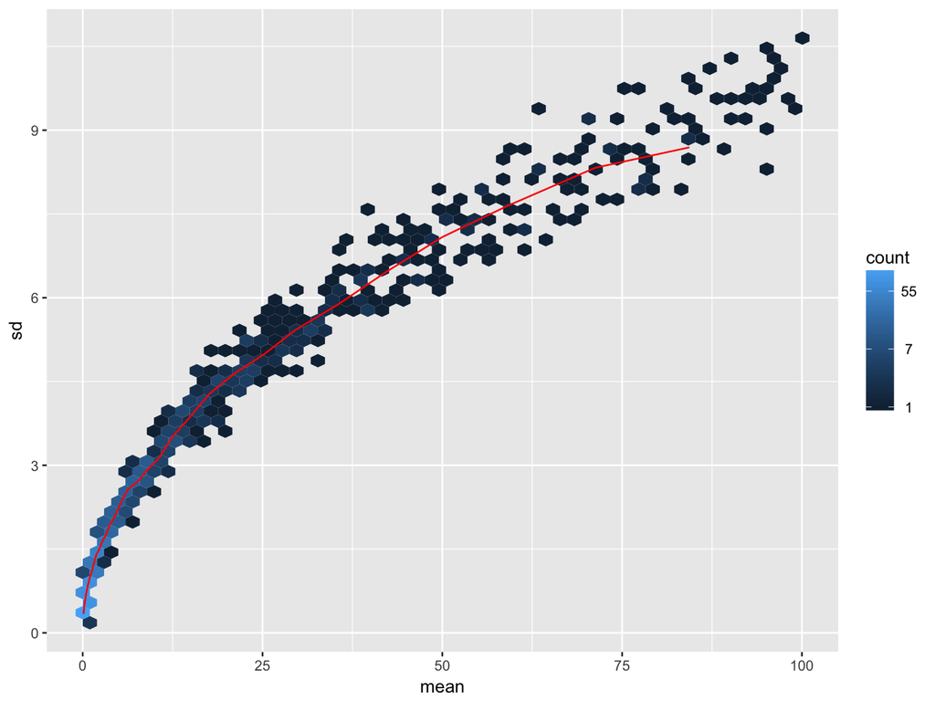

```r
lambda <- 10^seq(from = -1, to = 2, length = 1000)
cts <- matrix(rpois(1000*100, lambda), ncol = 100)
library("vsn")
meanSdPlot(cts, ranks = FALSE)
```

And for logarithm-transformed counts:

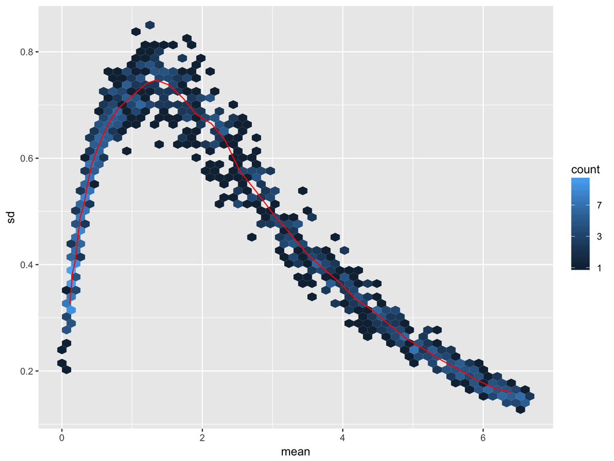

```r
log.cts.one <- log2(cts + 1)
meanSdPlot(log.cts.one, ranks = FALSE)
```

The logarithm with a small pseudocount amplifies differences when the values are close to 0. The low count genes with low signal-to-noise ratio will overly contribute to sample-sample distances and PCA plots.

*DESeq2* offers two transformations for count data that stabilize the variance across the mean. I recommend the and the *variance stabilizing transformation* implemented in the `vst` function. The VST is much faster to compute and is less sensitive to high count outliers than the other approach the regularized log (`rlog`). The function `vst` returns an object based on the *SummarizedExperiment* class that contains the stabilized values in its *assay* slot.

```r
vsd <- vst(dds, blind = FALSE)
head(assay(vsd), 3)
```

```
##                 SRR1039508 SRR1039509 SRR1039512 SRR1039513 SRR1039516
## ENSG00000000003   9.742340   9.430742   9.867872   9.646127  10.183344
## ENSG00000000419   9.334009   9.582000   9.486456   9.523397   9.427605
## ENSG00000000457   8.765748   8.698941   8.651978   8.732909   8.593308
##                 SRR1039517 SRR1039520 SRR1039521
## ENSG00000000003   9.880660  10.010591   9.640065
## ENSG00000000419   9.575154   9.326341   9.509553
## ENSG00000000457   8.703164   8.762420   8.724586
```

`blind = FALSE` regresses out variability due to experiment factors before estimating the mean-variance trend. For a fully *unsupervised* transformation, set `blind = TRUE` (which is the default).

The `rlog` transformation has a similar API to `vst`.

```r
rld <- rlog(dds, blind = FALSE)
head(assay(rld), 3)
```

```
##                 SRR1039508 SRR1039509 SRR1039512 SRR1039513 SRR1039516
## ENSG00000000003   9.385683   9.052608   9.516875   9.285338   9.839085
## ENSG00000000419   8.869616   9.138271   9.036116   9.075295   8.972126
## ENSG00000000457   7.961369   7.881385   7.824079   7.921490   7.751699
##                 SRR1039517 SRR1039520 SRR1039521
## ENSG00000000003   9.530311   9.663255   9.277699
## ENSG00000000419   9.131824   8.861534   9.060905
## ENSG00000000457   7.886441   7.957121   7.912123
```

# Sample distances

A useful first step in an RNA-seq analysis is often to assess overall similarity between samples: Which samples are similar to each other, which are different? Does this fit to the expectation from the experiment’s design?

We use the R function *dist* to calculate the Euclidean distance between samples. To ensure we have a roughly equal contribution from all genes, we use it on the rlog-transformed data. We need to transpose the matrix of values using *t*, because the *dist* function expects the different samples to be rows of its argument, and different dimensions (here, genes) to be columns.

```r
sampleDists <- dist(t(assay(rld)))
sampleDists
```

```
##            SRR1039508 SRR1039509 SRR1039512 SRR1039513 SRR1039516
## SRR1039509   45.69859
## SRR1039512   39.25239   54.90828
## SRR1039513   62.63201   44.52740   48.72579
## SRR1039516   44.50557   59.06364   43.57856   63.74275
## SRR1039517   64.49410   51.44882   59.22962   49.87992   47.48200
## SRR1039520   39.57693   57.46259   36.74434   58.49014   46.40786
## SRR1039521   63.36124   45.05732   57.87616   36.49484   65.54600
##            SRR1039517 SRR1039520
## SRR1039509
## SRR1039512
## SRR1039513
## SRR1039516
## SRR1039517
## SRR1039520   63.59942
## SRR1039521   52.31695   50.13430
```

What classifier have we learned about that would make immediate use of this matrix?

If we don’t provide `sampleDists` to the `clustering_distance` argument of the *pheatmap* function, it would calculate distances between the rows/columns of the distance matrix, which is kind of non-sense.

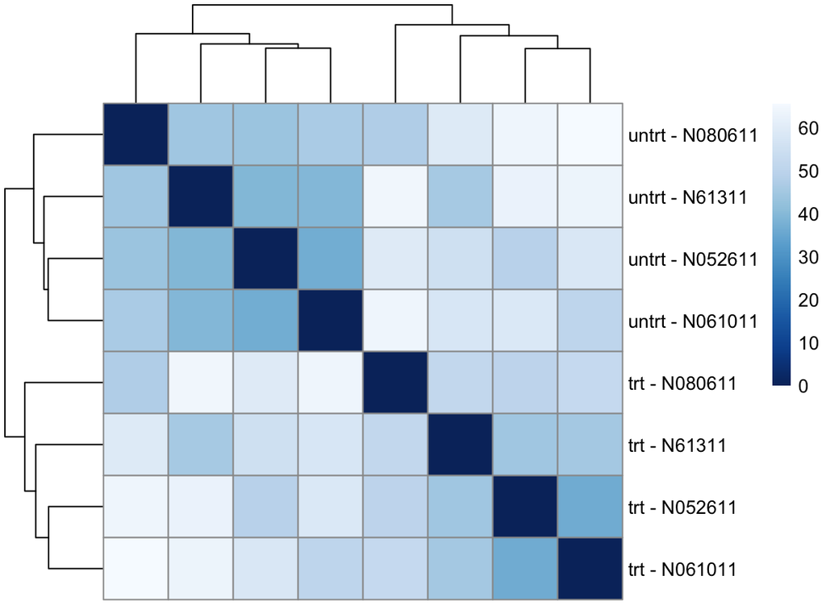

```r
library("pheatmap")
library("RColorBrewer")
sampleDistMatrix <- as.matrix( sampleDists )
rownames(sampleDistMatrix) <- paste( rld$dex, rld$cell, sep = " - " )
colnames(sampleDistMatrix) <- NULL
colors <- colorRampPalette( rev(brewer.pal(9, "Blues")) )(255)
pheatmap(sampleDistMatrix,
         clustering_distance_rows = sampleDists,
         clustering_distance_cols = sampleDists,
         col = colors)
```

# PCA

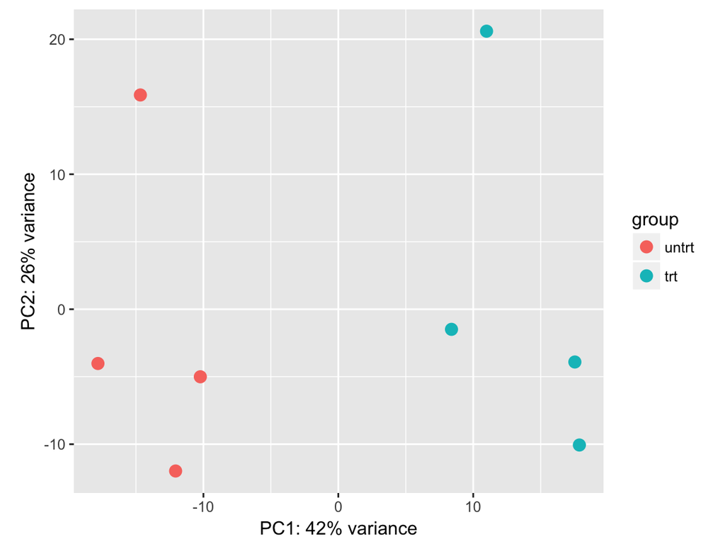

```r
plotPCA(rld, intgroup = c("dex"))
```

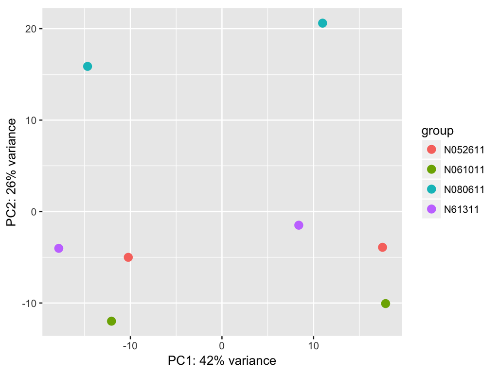

```r
plotPCA(rld, intgroup = c("cell"))
```

- What do the percentages mean?

# MDS plots

*multidimensional scaling* (MDS) is similar to PCA (in fact classic Torgerson MDS it is just doing PCA on a distance matrix). This is useful when we don’t have a matrix of data, but only a matrix of distances. Here we compute the MDS for the distances calculated from the *rlog* transformed counts and plot these in a figure below.

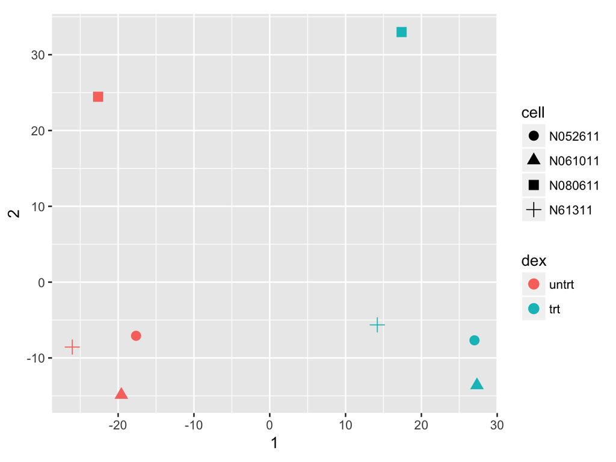

```r
mds <- as.data.frame(colData(rld))  %>%
         cbind(cmdscale(sampleDistMatrix))
ggplot(mds, aes(x = `1`, y = `2`, color = dex, shape = cell)) +
  geom_point(size = 3) + coord_fixed()
```

**MDS plot using rlog-transformed values.**

However, there are a number of extensions of MDS beyond the classical algorithm that are no longer equivalent to PCA, so the notion of reconstructing a dissimilarity matrix in 2D is a useful one.

# The canonical heatmap

In the sample distance heatmap made previously, the dendrogram at the side shows us a hierarchical clustering of the samples. Such a clustering can also be performed for the genes. Since the clustering is only relevant for genes that actually carry a signal, one usually would only cluster a subset of the most highly variable genes. Here, for demonstration, let us select the 20 genes with the highest variance across samples. We will work with the *rlog* transformed counts:

```r
library("genefilter")
topVarGenes <- head(order(rowVars(assay(rld)), decreasing = TRUE), 20)
```

We center each genes’ values across samples, and plot a heatmap (figure below). Centering both makes the color scheme more interpretable and alters the distance calculation, hence clustering, generally for the better. We provide a *data.frame* that instructs the *pheatmap* function how to label the columns.

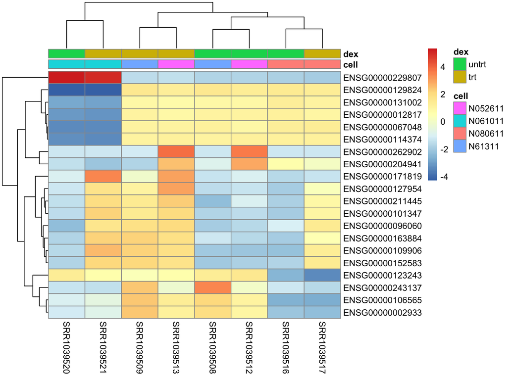

```r
mat  <- assay(rld)[ topVarGenes, ]
mat  <- mat - rowMeans(mat)
anno <- as.data.frame(colData(rld)[, c("cell","dex")])
pheatmap(mat, annotation_col = anno)
```

**Heatmap of relative rlog-transformed values across samples.**

# Batch effects

Batch effects are a fact of life in high-throughput biology because of the complex dependence of steps in an experiment. Consider the microarray:

1. Get cDNA (how degraded is your sample, how pure is your cell or tissue type)
2. Hybridize: concentration, temperature, time
3. Wash: time, temperature, astringency
4. Chip effects – lot.

Although variation in each step ought to be minimized, they are not a sin, but rather an unavoidable source of variability. Blocking, randomization and replication is the only solution. Fortunately, it is a powerful solution!

# Minimizing batch effects

The discussion on variance stabilizing transformations and normalization provides some analytic tools to minimize batch effects. Good experimental technique provides biological ways to minimize batch effects.

Unfortunately, these techniques will not always correct for batch effects. Technical variation due to batch effects might only affect a subset of the genes.

[figure not shown]

“For a published bladder cancer microarray data set obtained using an Affymetrix platform, we obtained the raw data for only the normal samples. Here, green and orange represent two different processing dates.”

# Adjusting for batch effects

**Two scenarios:**

1. You have information about the batch variable
   - Use your batch effect as a covariate in your analysis (e.g. limma or ComBat).
2. You suspect a batch effect, but you don’t know where it is coming from
   - The batch effect needs to be estimated first and then corrected for, by adding the estimated variables as co-variates

# Singular value decomposition

Let $X$ be a matrix of size $m\times n$ ($m \ge n$) and rank $r\le n$ then we can decompose $X$ as

$$X=UDV^T$$

- U is the matrix of left singular vectors (eigenassays)
- V is the matrix of right singular vectors (eigengenes)
- D is the matrix of singular values (eigenvalues)

$U^TU=VV^T=I$ (orthogonal vectors)

$D=diag(d_1, \dots, d_n)$ where $d_l\ge 0$ and $d_{r+1}=\dots=d_n=0$

$X_i=\sum_j u_{ij}d_j\mathbf{v}_j$, which can be interpreted as a change of coordinate

## Relationship to principale component analysis

$X=UDV^T$, and we have $X^TX=VDU^TUDV^T=VD^2V^T$

What happens if the rows of X are scaled?

# Surrogate variable analysis

Let $X_{m\times n}=(x_1,..,x_m)^T$ be the matrix of normalized expression values, with $n$ arrays and $m$ genes. Let $y=(y_1,..,y_n)^T$ be a vector of length $n$ representing the primary variable of interest (e.g covariates, vector of unknown coefficients). Without loss of generality model $x_{ij}=\mu_i+f_i( y_j) + e_{ij}$, where $\mu_i$ is the baseline level of expression, $f_i(y_j)=\mathbb{E}(x_{ij} | y_j)-\mu_i$ gives the relationship between measured variable of interest and gene $i$, and $e_{ij}$ is random noise with mean zero.

Suppose there are $L$ biologically meaningful unmodeled factors, such as age, environmental exposure, genotype, etc. Let $\mathbf{G} = (g_{l1},...,g_{ln})$ be a set of factors across all $n$ arrays, for $l=1,2,...,L$. Our model becomes:

$$x_{ij}=\mu_i + f_i(y_j) + \boldsymbol{\Gamma} \mathbf{G} + e^*_{ij},$$
where $\boldsymbol{\Gamma}$ is $m \times L$ and $\mathbf{G}$ is $L \times n$.

Leek and Storey propose to use singular value decomposition to approximate $\boldsymbol{\Gamma} \mathbf{G}$. Computationally, this is done in two steps:

1. Detect unmodeled factors
2. Construct surrogate variables

# Detect unmodeled factors

The main idea is as follows:

- Compute the residual matrix $r_{ij} = x_{ij}- \hat{\mu}_i - \hat{f}_i(y_j)$
- Perform the SVD of $R=(r_{ij})$
- Determine the number $K$ of significant components through a permutation procedure.

# Construct surrogate variables

If we used residual matrix directly, then we force the $\mathbf{G}$ eigen-factors (which Leek somewhat-confusingly calls eigengenes) to be orthogonal to the treatment variables. But we don’t want to assume the batch variables are necessarily orthogonal to treatment. Instead, we assume that the most of the signal comes from a few genes, and take the SVD of this smaller set. It’s not clear to me, exactly what statistical model, if any, this is supposed to correspond to.

1. Compute the residual matrix $r_{ij} = x_{ij} - \hat{\mu}_i - \hat{f}_i(y_j)$
2. Perform the SVD of $R=(r_{ij})$

Let $e_k=(e_{k1},...,e_{kn})^T$ be the $k$-th column of $V$ (for $k=1,...,n$). These $e_k$ are the residual eigengenes and represent orthogonal residual signals independent of the signal due to the primary variable.

2. Regress $e_k$ on the $x_i$ to access the significance of the $k$-th factor on gene $i$
3. Use the selected genes to form a reduced expression matrix and repeat 1. The estimated factor will form the basis for the surrogate variables
4. In any subsequent analysis include these factors in your model

# Using the sva package

```r
library("sva")
```

```r
dat  <- counts(dds, normalized = TRUE)
idx  <- rowMeans(dat) > 1
dat  <- dat[idx, ]
mod  <- model.matrix(~ dex, colData(dds))
mod0 <- model.matrix(~   1, colData(dds))
svseq <- svaseq(dat, mod, mod0, n.sv = 2)
```

```
## Number of significant surrogate variables is:  2
## Iteration (out of 5 ):1  2  3  4  5
```

```r
svseq$sv
```

```
##            [,1]        [,2]
## [1,]  0.2481108 -0.52600157
## [2,]  0.2629867 -0.58115433
## [3,]  0.1502704  0.27428267
## [4,]  0.2023800  0.38419545
## [5,] -0.6086586 -0.07854931
## [6,] -0.6101210 -0.02923693
## [7,]  0.1788509  0.25708985
## [8,]  0.1761807  0.29937417
```

Do a little light filtering and set up the model.

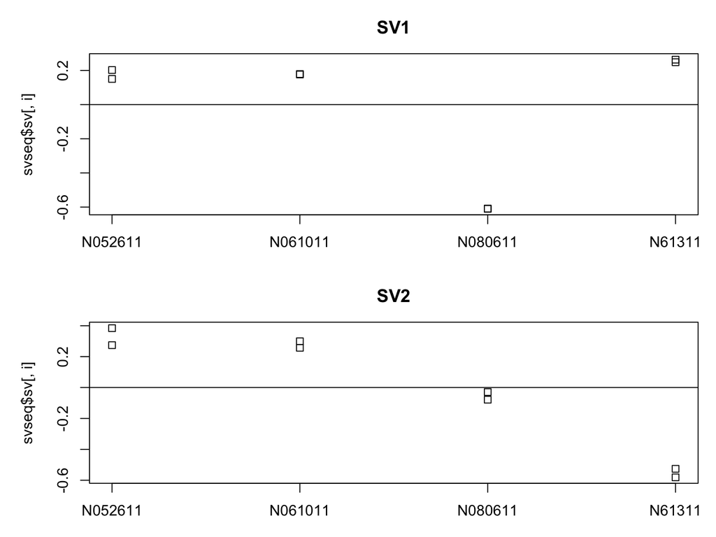

```r
par(mfrow = c(2, 1), mar = c(3,5,3,1))
for (i in 1:2) {
  stripchart(svseq$sv[, i] ~ dds$cell, vertical = TRUE, main = paste0("SV", i))
  abline(h = 0)
 }
```

**Surrogate variables 1 and 2 plotted over cell line.** Here, we know the hidden source of variation (cell line), and therefore can see how the SVA procedure is able to identify a source of variation which is correlated with cell line.

In order to adjust for the surrogate variables, we simply add these two surrogate variables as columns to the *DESeqDataSet* and then add them to the design:

```r
ddssva <- dds
ddssva$SV1 <- svseq$sv[,1]
ddssva$SV2 <- svseq$sv[,2]
design(ddssva) <- ~ SV1 + SV2 + dex
```

We could then produce results controlling for surrogate variables by running *DESeq* with the new design:

```r
ddssva =  DESeq(ddssva)
```

# Comparison to cell line known

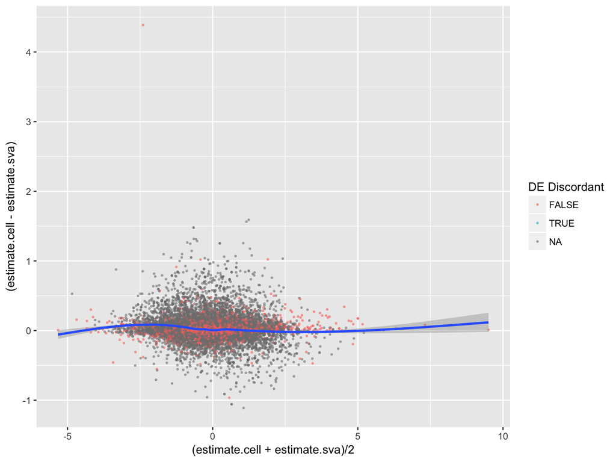

```r
library(biobroom)
sva_res = results(ddssva) %>% tidy()
comparison = results(dds) %>% tidy() %>% left_join(sva_res, suffix = c('.cell', '.sva'), by = 'gene')
ggplot(comparison, aes(x = (estimate.cell + estimate.sva)/2, y = (estimate.cell - estimate.sva))) + geom_point(aes(color = (p.adjusted.sva < .05 & p.adjusted.cell > .1)), size = .5, alpha = .5) + geom_smooth() + scale_color_discrete('DE Discordant')
```

# ComBat

The ComBat method of Johnson, Li and Rabinovic (2006) posits a hierarchical model for batch effects and shrinks around a common mean. It also allows for heteroscedasticity. See https://academic.oup.com/biostatistics/article-lookup/doi/10.1093/biostatistics/kxj037#fd2.2 for details.

# Bibliography

Anders, Simon, Paul T. Pyl, and Wolfgang Huber. 2015. “HTSeq – a Python framework to work with high-throughput sequencing data.” *Bioinformatics* 31 (2): 166–69. doi:10.1093/bioinformatics/btu638.

Benjamini, Yoav, and Yosef Hochberg. 1995. “Controlling the False Discovery Rate: A Practical and Powerful Approach to Multiple Testing.” *Journal of the Royal Statistical Society. Series B (Methodological)* 57 (1): 289–300. http://www.jstor.org/stable/2346101.

Flicek, Paul, M. Ridwan Amode, Daniel Barrell, Kathryn Beal, Konstantinos Billis, Simon Brent, Denise Carvalho-Silva, et al. 2014. “Ensembl 2014.” *Nucleic Acids Research* 42 (D1): D749–D755. doi:10.1093/nar/gkt1196.

Hardcastle, Thomas, and Krystyna Kelly. 2010. “baySeq: Empirical Bayesian methods for identifying differential expression in sequence count data.” *BMC Bioinformatics* 11 (1): 422+. doi:10.1186/1471-2105-11-422.

Kent, W. James, Charles W. Sugnet, Terrence S. Furey, Krishna M. Roskin, Tom H. Pringle, Alan M. Zahler, and David Haussler. 2002. “The human genome browser at UCSC.” *Genome Research* 12 (6). Cold Spring Harbor Laboratory Press: 996–1006. doi:10.1101/gr.229102.

Law, Charity W., Yunshun Chen, Wei Shi, and Gordon K. Smyth. 2014. “Voom: precision weights unlock linear model analysis tools for RNA-seq read counts.” *Genome Biology* 15 (2). BioMed Central Ltd: R29+. doi:10.1186/gb-2014-15-2-r29.

Lawrence, Michael, Wolfgang Huber, Hervé Pagès, Patrick Aboyoun, Marc Carlson, Robert Gentleman, Martin T. Morgan, and Vincent J. Carey. 2013. “Software for Computing and Annotating Genomic Ranges.” Edited by Andreas Prlic. *PLoS Computational Biology* 9 (8). Public Library of Science: e1003118+. doi:10.1371/journal.pcbi.1003118.

Leng, N., J. A. Dawson, J. A. Thomson, V. Ruotti, A. I. Rissman, B. M. G. Smits, J. D. Haag, M. N. Gould, R. M. Stewart, and C. Kendziorski. 2013. “EBSeq: an empirical Bayes hierarchical model for inference in RNA-seq experiments.” *Bioinformatics* 29 (8). Oxford University Press: 1035–43. doi:10.1093/bioinformatics/btt087.

Liao, Y., G. K. Smyth, and W. Shi. 2014. “featureCounts: an efficient general purpose program for assigning sequence reads to genomic features.” *Bioinformatics* 30 (7). Oxford University Press: 923–30. doi:10.1093/bioinformatics/btt656.

Robinson, M. D., D. J. McCarthy, and G. K. Smyth. 2009. “edgeR: a Bioconductor package for differential expression analysis of digital gene expression data.” *Bioinformatics* 26 (1). Oxford University Press: 139–40. doi:10.1093/bioinformatics/btp616.

Schurch, Nicholas J., Pieta Schofield, Marek Gierlinski, Christian Cole, Alexander Sherstnev, Vijender Singh, Nicola Wrobel, et al. 2016. “How Many Biological Replicates Are Needed in an Rna-Seq Experiment and Which Differential Expression Tool Should You Use?” 22 (6): 839–51. doi:10.1261/rna.053959.115.

Soneson, Charlotte, Michael I. Love, and Mark Robinson. 2015. “Differential analyses for RNA-seq: transcript-level estimates improve gene-level inferences.” *F1000Research* 4 (1521). doi:10.12688/f1000research.7563.1.

Wu, Hao, Chi Wang, and Zhijin Wu. 2013. “A new shrinkage estimator for dispersion improves differential expression detection in RNA-seq data.” *Biostatistics* 14 (2). Oxford University Press: 232–43. doi:10.1093/biostatistics/kxs033.

[^1]: See Harold Pimentel’s (excellent blog post)[https://haroldpimentel.wordpress.com/2014/05/08/what-the-fpkm-a-review-rna-seq-expression-units/] for more.
[^2]: Again, see https://haroldpimentel.wordpress.com/category/statistics-2/